# RT-PCR positivity duration

Pablo Perez

19/10/2020

In *[Eurosurveillance 2020 Jul 30; 25(30): 2001292](https://dx.doi.org/10.2807/1560-7917.ES.2020.25.30.2001292)*, Omar et al. analysed data of consecutive RT-qPCR results in 537 symptomatic patients with mild COVID-19 in home quarantine, between 28 February to 6 June 2020 in Rhineland-Palatinate, Germany. Table 1 presents their reported data on the population with an RT-qPCR positive for SARS-CoV-2 RNA at mean (95%CI) days after symptom onset. They reported a **median time to testing negative of 20 days (IQR 16-28)**.

### Table 1. Cumulative population proportions

```r
df[,2:4]
```

```
##    Proportion Number        Mean..95.CI.
## 1       0.990    532    2.24 (1.88-2.61)
## 2       0.975    524    3.31 (2.85-3.77)
## 3       0.950    510    4.48 (3.89-5.07)
## 4       0.900    483    6.15 (5.33-6.97)
## 5       0.750    403   9.74 (8.42-11.07)
## 6       0.500    269  14.96 (13.01-16.9)
## 7       0.250    134 21.43 (18.96-23.91)
## 8       0.100     54  28.28 (25.5-31.06)
## 9       0.050     27 32.82 (29.93-35.72)
## 10      0.025     13    37.01 (34.03-40)
## 11      0.010      5 42.16 (39.04-45.29)
## 12         NA     NA
```

## Simulated study population

For `i in 1:1,000`, at each iteration of time `t`, sample `n` random numbers
$$\ n \ = \space n_{t} \ - \ n_{t-1}$$
from a normal distribution with mean = `mu` and sd = `sigma`, given upper and lower bounds of observed time.

At each step `i`, fit a gamma distribution by maximum likelihood, obtain its parameters and then average across all 1,000 iterations.

```
## [1] "Shape = "         "3.43168428467173"
```

```
## [1] "Scale = "         "5.58083094545172"
```

```
## [1] "Rate = "          "0.17918478623958"
```

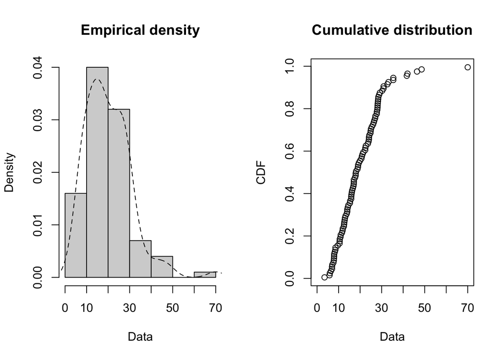

```
##    Min. 1st Qu.  Median    Mean 3rd Qu.    Max.
##    3.48   12.53   18.03   20.09   26.71   69.99
```

## Fit distribution directly

Using Omar et al.’s reported cumulative `proportion` and `mean` time, fit distribution lines and obtain parameters.

```
## The fitting procedure 'L-BFGS-B' was successful!
```

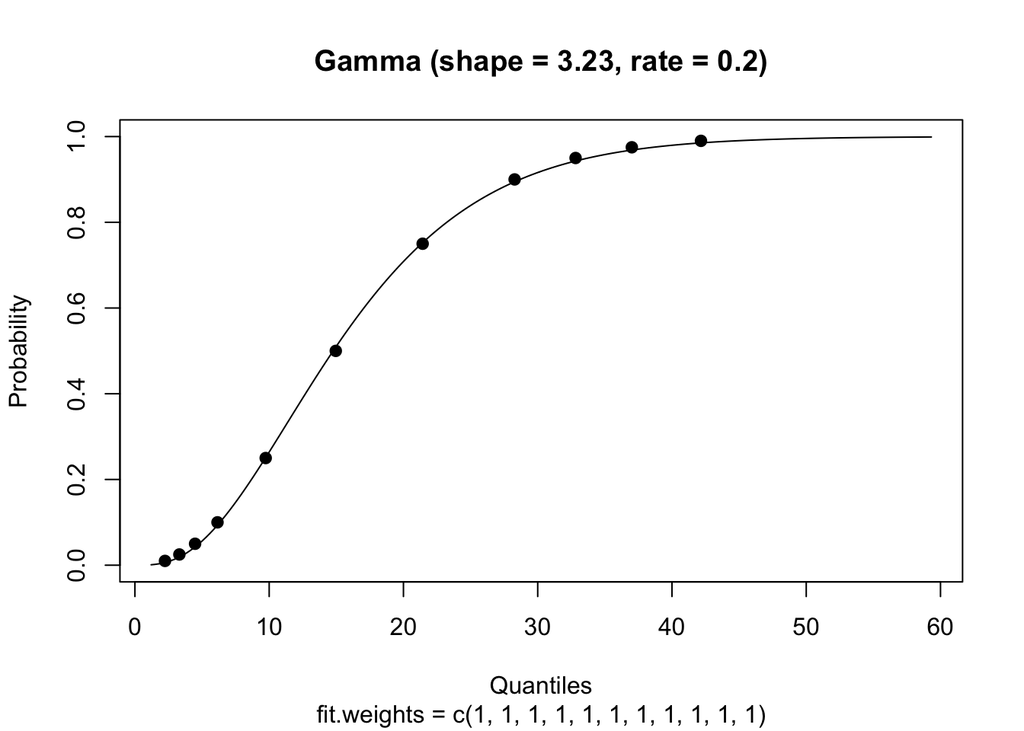

```
##    shape     rate
## 3.229555 0.196583
```

```r
get.gamma.par(p, q, show.output = FALSE, plot = TRUE, tol = 0.001)
```

Obtain a gamma distributed random sample of `n = 1000` and test distribution fit.

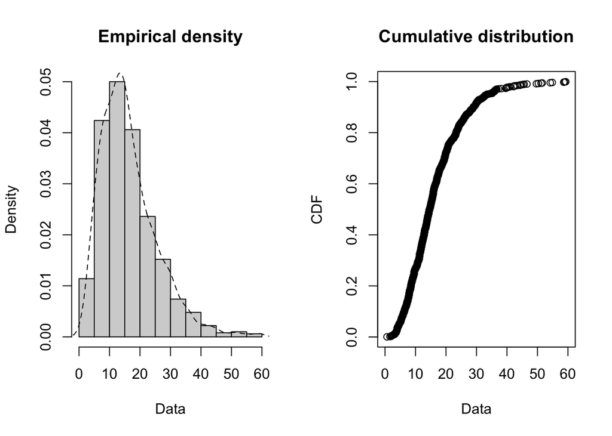

```
##    Min. 1st Qu.  Median    Mean 3rd Qu.    Max.
##  0.6656  9.5631 14.6209 16.3911 20.7583 59.2713
```

## Fit gamma accelerated failure time regression

Using simulated datasets above, let’s fit a gamma accelerated failure time regression model and obtain parameters.

### Figure 1. Simulated population

```r
print(fit.edata,print.rmean=T)
```

```
## Call: survfit(formula = edata.surv ~ 1, type = "kaplan-meier", conf.type = "log-log")
##
##          n     events     *rmean *se(rmean)     median    0.95LCL    0.95UCL
##     100.00     100.00      20.09       1.06      18.03      15.97      21.51
##     * restricted mean with upper limit =  70
```

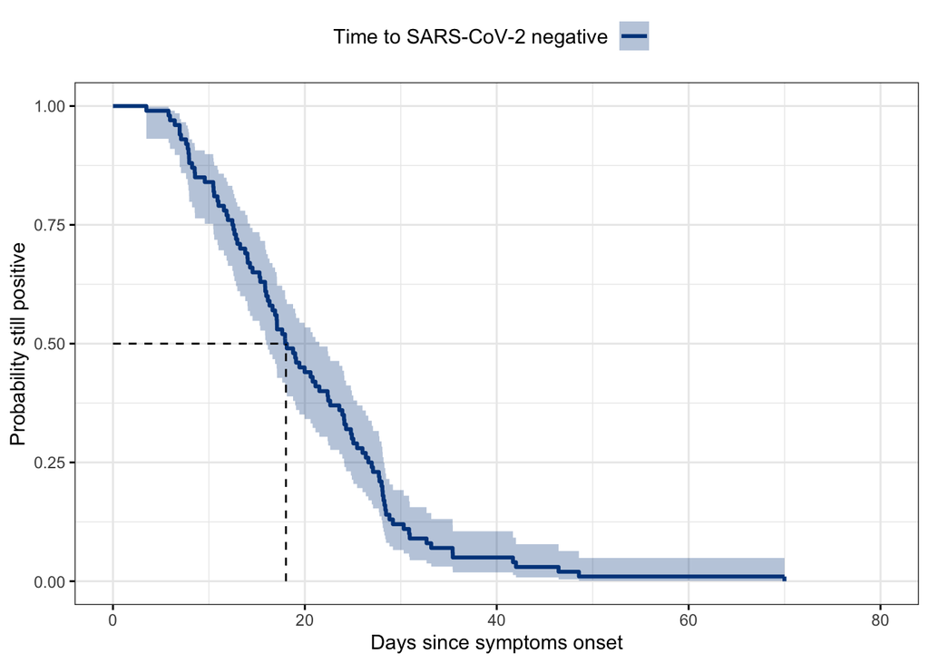

```r
ggsurvplot(fit.edata,data=edata,
           palette="lancet",
           ggtheme=theme_bw(),
           surv.median.line="hv",
           legend.title="Time to SARS-CoV-2 negative",
           legend.labs="",xlab="Days since symptoms onset",
           ylab="Probability still positive")
```

```r
fit.gamma.edata <- flexsurvreg(edata.surv~1, dist="gamma")
fit.gamma.edata
```

```
## Call:
## flexsurvreg(formula = edata.surv ~ 1, dist = "gamma")
##
## Estimates:
##        est     L95%    U95%    se
## shape  3.7960  2.9097  4.9523  0.5150
## rate   0.1889  0.1422  0.2510  0.0274
##
## N = 100,  Events: 100,  Censored: 0
## Total time at risk: 2009.422
## Log-likelihood = -365.8642, df = 2
## AIC = 735.7284
```

### Figure 2. Direct fit

```r
print(fit.edata.2,print.rmean=T)
```

```
## Call: survfit(formula = edata.2.surv ~ 1, type = "kaplan-meier", conf.type = "log-log")
##
##          n     events     *rmean *se(rmean)     median    0.95LCL    0.95UCL
##   1000.000   1000.000     16.391      0.293     14.621     14.009     15.242
##     * restricted mean with upper limit =  59.3
```

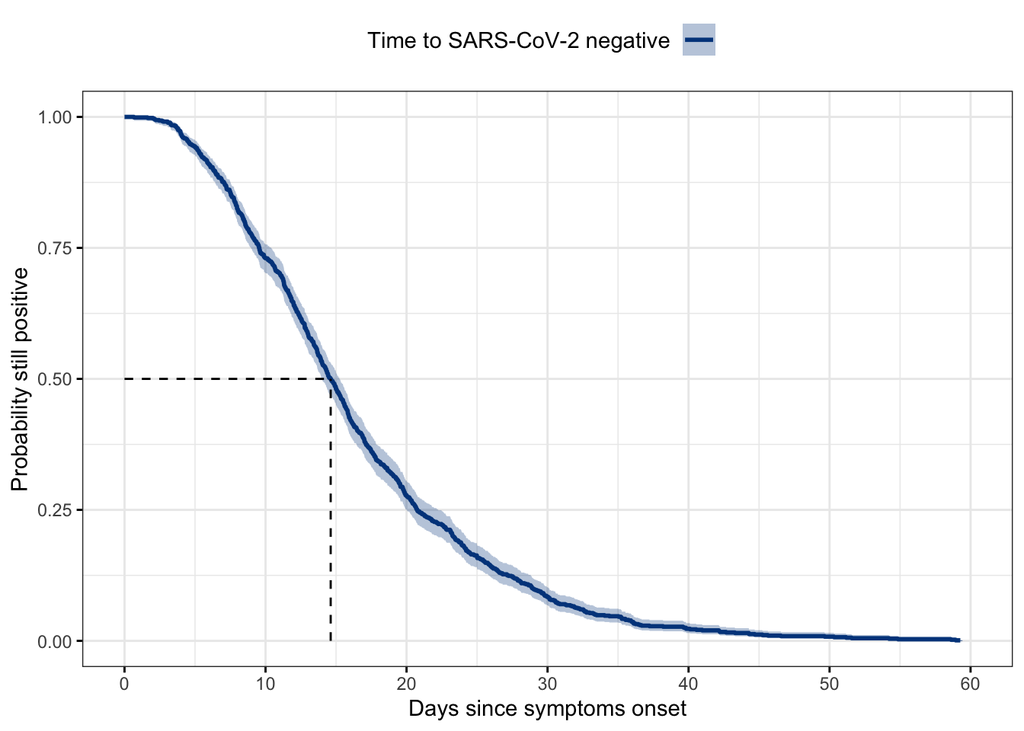

```r
ggsurvplot(fit.edata.2,data=edata.2,
           palette="lancet",
           ggtheme=theme_bw(),
           surv.median.line="hv",
           legend.title="Time to SARS-CoV-2 negative",
           legend.labs="",xlab="Days since symptoms onset",
           ylab="Probability still positive")
```

```r
fit.gamma.edata.2 <- flexsurvreg(edata.2.surv~1, dist="gamma")
fit.gamma.edata.2
```

```
## Call:
## flexsurvreg(formula = edata.2.surv ~ 1, dist = "gamma")
##
## Estimates:
##        est      L95%     U95%     se
## shape  3.21988  2.96191  3.50032  0.13719
## rate   0.19644  0.17947  0.21502  0.00906
##
## N = 1000,  Events: 1000,  Censored: 0
## Total time at risk: 16391.09
## Log-likelihood = -3519.196, df = 2
## AIC = 7042.391
```

## Fit Erlang distribution

```r
# Obtain ccdf of PCR positivity
q <- seq(0, 100, l = 21)
df.edata <- data.frame(x = fit.edata$surv,y = fit.edata$cumhaz, z = fit.edata$time)
ccdf_pcr <- data.frame()
for (i in 1:21) {
  x = q[i+1]
  ccdf_pcr[1,i] <- df.edata$y[x]
}
ccdf_pcr <- cbind(0,ccdf_pcr)
ccdf_pcr <- ccdf_pcr[,1:21]
rownames(ccdf_pcr) <- "pcr positive"

# obtain mean, median and IQR of progression durations
progression_durations <- data.frame(param = "m_Com",
                                    Q2.5 = mean(df.edata$z[2],df.edata$z[3]),
                                    Q50 = df.edata$z[50],
                                    Q97.5 = mean(df.edata$z[97],df.edata$z[98]),
                                    mean = mean(df.edata$z))

# pass parameters on to Lilith's functions
source("fit_Erlang.R") ## this is kept offline
```

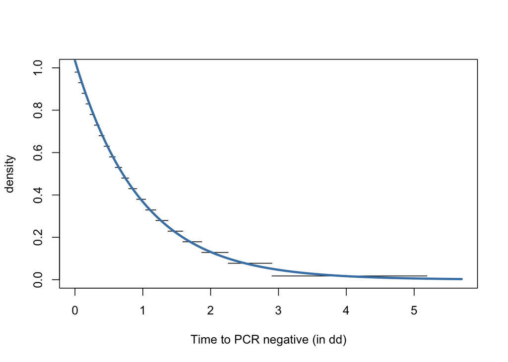

```r
# Print outputs
op_res # scaled Erlang parameters (normalised time)
```

```
## $s_min
## [1] 1
##
## $r_min
## [1] 1.033723
```

```r
scaled_gamma # re-scaled gamma (true time)
```

```
## [1] 0.05144379
```